# BlogEntry1

Zachary Palmore

5/17/2021

```r
library(tidyverse)
theme_set(theme_minimal())
```

## The Normality Assumption

In linear regression we often attempt to predict based on some data that represents reality. For this week’s post, we will take a look at how to assess an important assumption that must be made to predict accurately using linear regression. To understand how to assess normality we use data from an irrigation experiment in which a sprayer nozzle delivers a certain amount of water per trial. Our goal is to estimate the amount of water delivered per trial and predict how much will be delivered at a 20, 50, and 100 trials of this sprayer nozzle. A sample of this data is provided below.

```r
sprays <- read.csv("https://raw.githubusercontent.com/palmorezm/misc/master/Sprays.csv")
set.seed(41)
df <- sample_n(sprays, 100, replace = T)
colnames(df) <- c("Trial","Sprays","Diameter","Height")
head(df)
```

|  | Trial | Sprays | Diameter | Height |
| --- | --- | --- | --- | --- |
| 1 | 40 | 100 | 8.5 | 1000 |
| 2 | 35 | 23 | 8.5 | 253 |
| 3 | 5 | 91 | 8.5 | 728 |
| 4 | 96 | 73 | 8.5 | 657 |
| 5 | 72 | 31 | 8.5 | 279 |
| 6 | 58 | 67 | 8.5 | 670 |

```r
df <- df %>%
  mutate(vol = pi*(Diameter)*Height) %>%
  mutate(Liters = vol/1000)
head(df)
```

|  | Trial | Sprays | Diameter | Height | vol | Liters |
| --- | --- | --- | --- | --- | --- | --- |
| 1 | 40 | 100 | 8.5 | 1000 | 26703.538 | 26.703538 |
| 2 | 35 | 23 | 8.5 | 253 | 6755.995 | 6.755995 |
| 3 | 5 | 91 | 8.5 | 728 | 19440.175 | 19.440175 |
| 4 | 96 | 73 | 8.5 | 657 | 17544.224 | 17.544224 |
| 5 | 72 | 31 | 8.5 | 279 | 7450.287 | 7.450287 |
| 6 | 58 | 67 | 8.5 | 670 | 17891.370 | 17.891370 |

Notice that, in the calculation a new column with the volume measurement conversion from milliliters (mL) to liters (L) was computed. This should help us make sense of trends when plotting the number of sprays with the volume of water delivered. We visualize that plot with a few lines and check for linearity, that is, whether the data appears to follow some linear pattern.

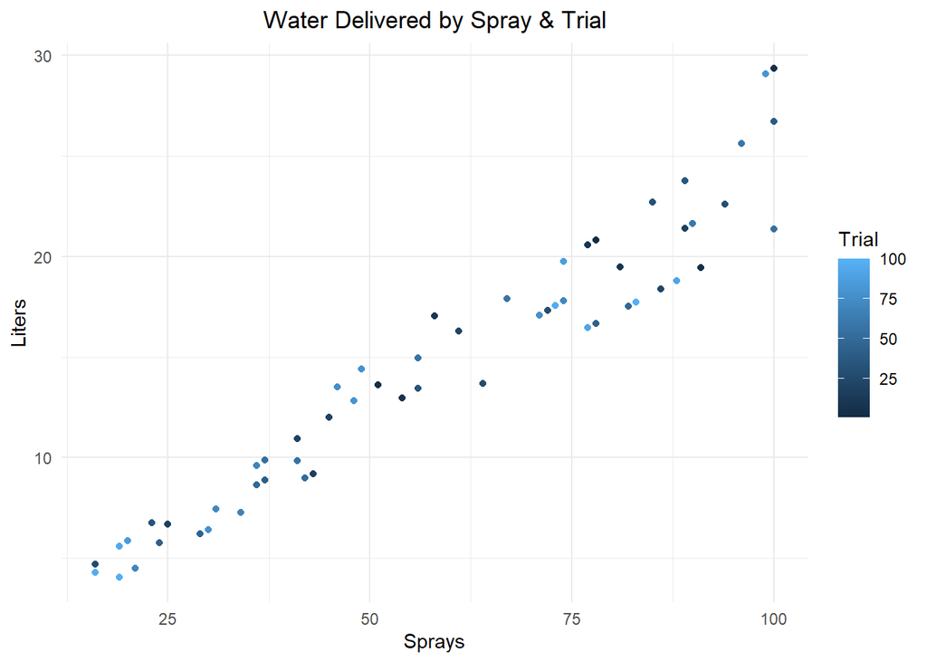

```r
df %>%
  ggplot(aes(Sprays, Liters)) +
  geom_point(aes(color=Trial)) +
  ggtitle("Water Delivered by Spray & Trial") +
  theme(plot.title = element_text(hjust = 0.5))
```

```r
df.lm <- lm(Sprays ~ Liters, df)
summary(df.lm)
```

```
##
## Call:
## lm(formula = Sprays ~ Liters, data = df)
##
## Residuals:
##     Min      1Q  Median      3Q     Max
## -11.549  -3.585  -1.938   3.280  17.618
##
## Coefficients:
##             Estimate Std. Error t value Pr(>|t|)
## (Intercept)  4.60616    1.49777   3.075  0.00272 **
## Liters       3.64073    0.09332  39.012  < 2e-16 ***
## ---
## Signif. codes:  0 '***' 0.001 '**' 0.01 '*' 0.05 '.' 0.1 ' ' 1
##
## Residual standard error: 6.928 on 98 degrees of freedom
## Multiple R-squared:  0.9395, Adjusted R-squared:  0.9389
## F-statistic:  1522 on 1 and 98 DF,  p-value: < 2.2e-16
```

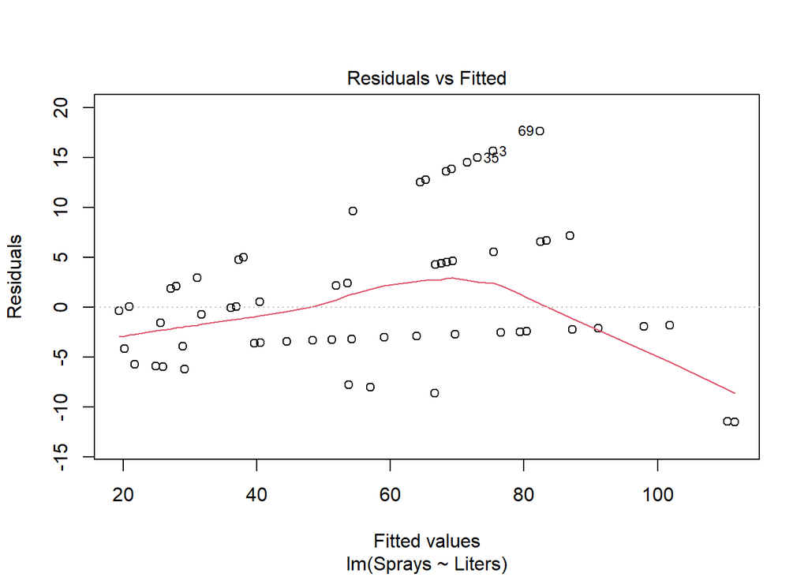

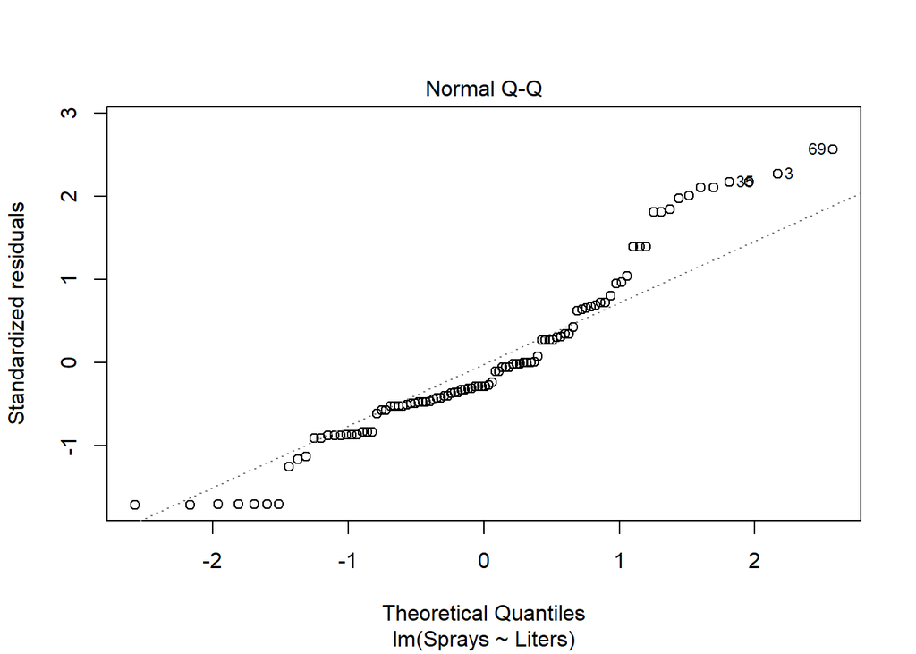

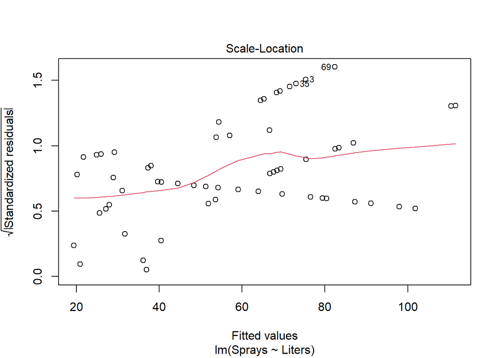

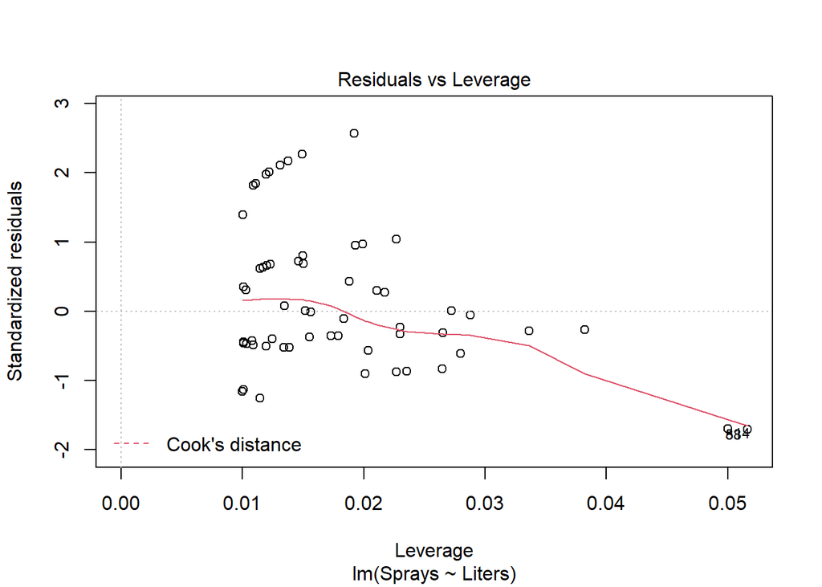

```r
plot(df.lm)
```